# Time Series Analysis on U.S. Suicide Rate

Xiran Wang

xiranwangwork@gmail.com

Department of Statistics, University of South Carolina

04/22/2019

## I.Background and Project Introduction

Every year, a million adults report making a suicide attempt, according to the U.S. Centers for Disease Control and Prevention (CDC). Worldwide, 800,000 people die due to suicide every year, according to the World Health Organization (WHO). Many people look at suicide as a mystery, because at an individual level, it is hard to see any signs before suicides, at a society level, suicides are usually involved mental illness caused by many various reasons. As a result, preventing a suicide seems to be more difficult. In addition, prevention on suicide action are involved study of many subjects, such as psychology ethology, sociology, and statistics, etc.

## II. Model Specification

### Step 1. Observation on the Raw Data Set

The plot of raw data shows that there is significant spike, and the raw data set looks quite nonstationary. it could cause inaccuracy to furfure model fitting. As a result, it is reasonable to consider doing difference on raw data set. After did difference, the differenced data improves much better. And it is close to stationary except some extreme values. Similarly, log- transformation is another common method to deal with raw data, however, there is no much change when use it on raw data set. When take the difference on logged data, the differenced logged data improve looks the as good as deferenced original data, so it is good to use a simplier one to fit models.

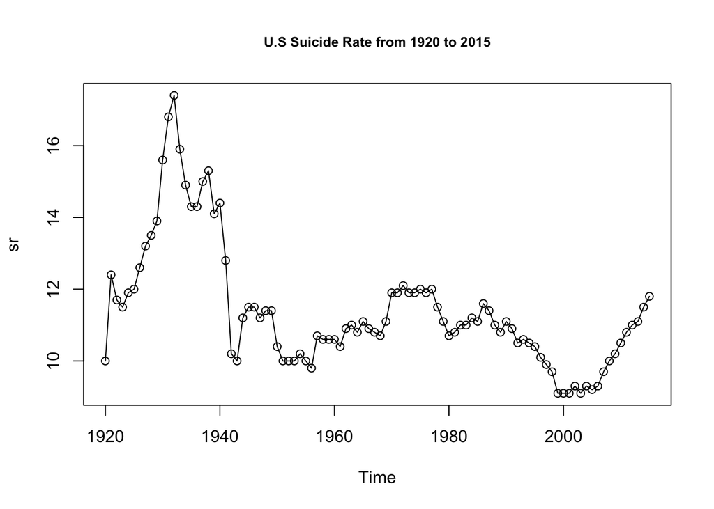

```r
# Data process
suicide.ts <- ts(suicide[,2], start=c(1920), frequency=1)

sr <- window(suicide.ts,start=1920,end=2015)

plot(sr,type='o', main='U.S Suicide Rate from 1920 to 2015',
     cex.main=c(0.8), cex.axis=c(0.8))
```

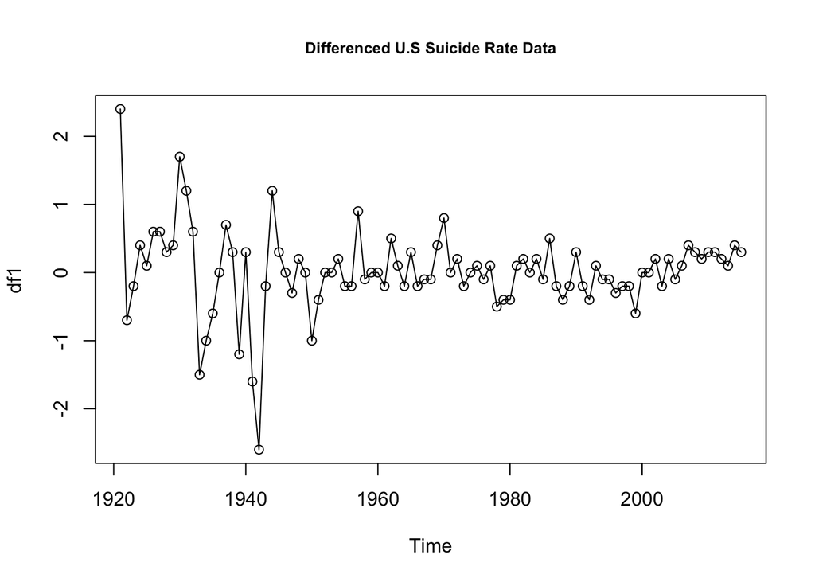

```r
lg    <- log(sr)
df1   <- diff(sr)
dflog <- diff(lg)

plot(df1,type='o', main='Differenced U.S Suicide Rate Data',
     cex.main=c(0.8), cex.axis=c(0.8))
```

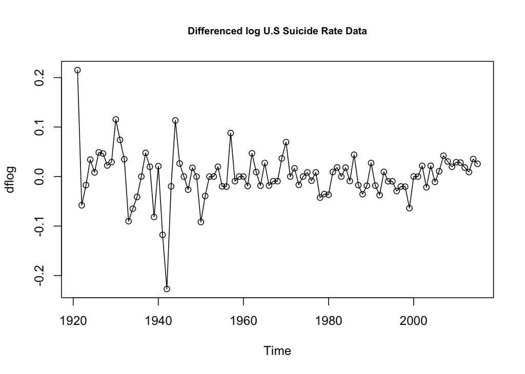

```r
plot(dflog,type='o', main='Differenced log U.S Suicide Rate Data',
     cex.main=c(0.8), cex.axis=c(0.8))
```

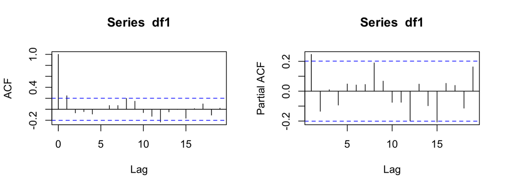

```r
par(mfrow=c(1,2))

acf(df1)
pacf(df1)
```

### Step 2. Comparision on candidate models

Based on observing the PACF, there is only one significant lag in lag-1. Combine the evidences from both ACF and PACF, start fitting the model by using ARIMA(1,1,1), ARIMA(0,1,1) and ARIMA(1,1,0). In the fact, the ARIMA(0,1,1) will be the best candidate model for the data set since it has the smallest both AIC and BIC values. The conparsion is in the following.

```r
par.est <- function(p,q){

    model <- arima(sr, order=c(p,1,q),method='ML') # ARIMA(1,1,1) using maximum likelihood
    coeff <- model$coef
    aic   <- AIC(model)
    bic   <- BIC(model)
    out   <- list(coeff,aic,bic)
    return(out)
}


coef  <- rbind(cbind(par.est(1,0)[[1]],NA), cbind(NA,par.est(0,1)[[1]]),  par.est(1,1)[[1]] )
AICs  <- rbind(par.est(1,0)[2],par.est(0,1)[2],par.est(1,1)[2] )
BICs  <- rbind( par.est(1,0)[3],par.est(0,1)[3],par.est(1,1)[3])
table <- cbind(coef,AICs,BICs)

colnames(table) <- c("ar1 coef","ma1 coef","AIC","BIC")
rownames(table) <- c("ARIMA(1,1,0)","ARIMA(0,1,1)","ARIMA(1,1,1)")

kable(table)%>%
  kable_styling()
```

|  | ar1 coef | ma1 coef | AIC | BIC |
| --- | --- | --- | --- | --- |
| ARIMA(1,1,0) | 0.29086267580524 | NA | 172.445240269251 | 177.552994052452 |
| ARIMA(0,1,1) | NA | 0.430136803674024 | 169.162538614682 | 174.270292397883 |
| ARIMA(1,1,1) | -0.20223969769846 | 0.591256222786664 | 170.431672880104 | 178.093303554906 |

## III. Fitting and diagnostics

```r
arma.d <- arima(sr, order=c(0,1,1),method='ML') # ARIMA(1,1,1) using maximum likelihood
```

```r
arma.d <- arima(sr, order=c(0,1,1),method='ML') # ARIMA(1,1,1) using maximum likelihood
Box.test(arma.d$resid,type="Ljung-Box")
```

```
##
##  Box-Ljung test
##
## data:  arma.d$resid
## X-squared = 1.3346, df = 1, p-value = 0.248
```

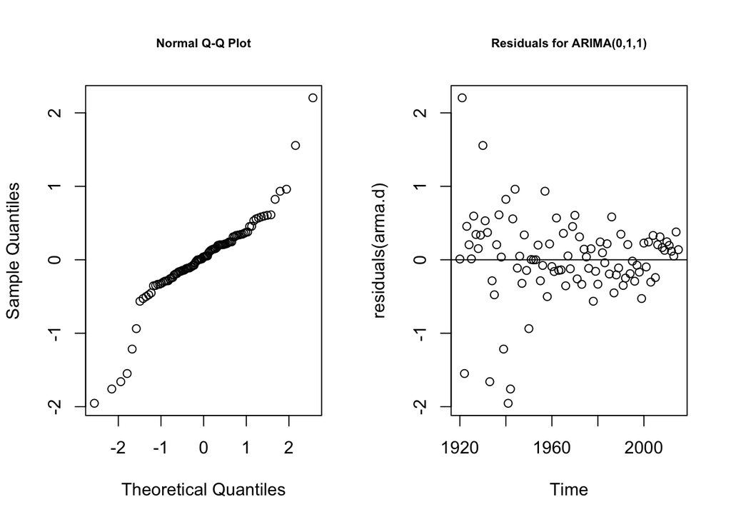

```r
par(mfrow=c(1,2))
qqnorm(residuals(arma.d),cex.main=c(0.7))

plot(residuals(arma.d),type='p',main='Residuals for ARIMA(0,1,1)',cex.main=c(0.7))
abline(h=0)
```

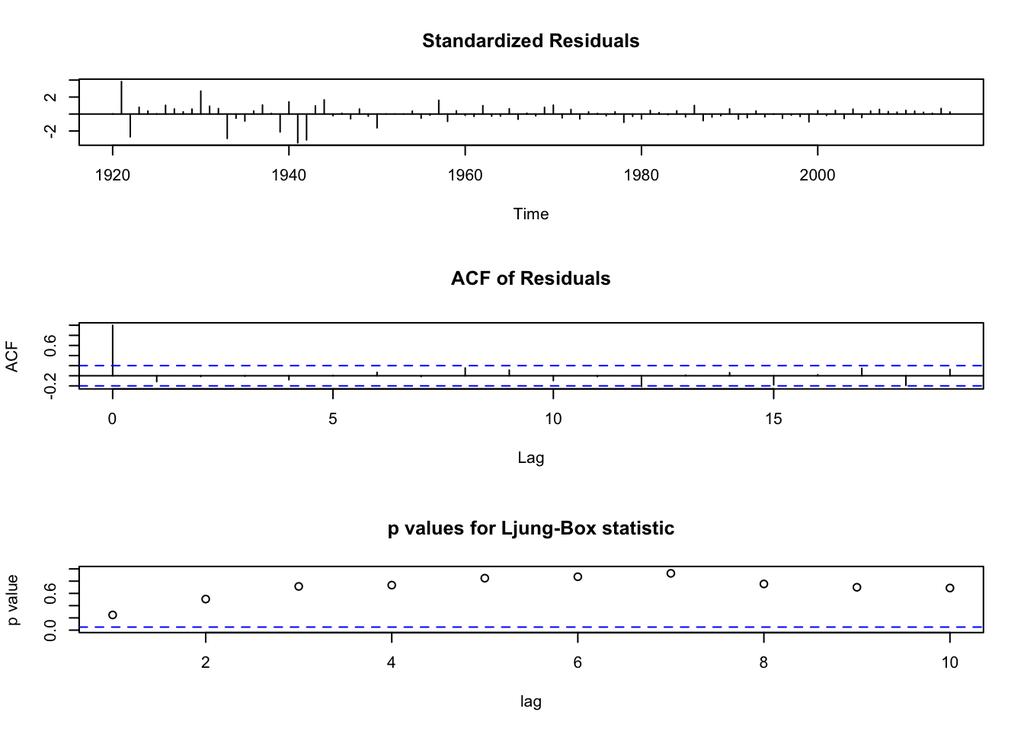

```r
par(mfrow=c(1,1))

tsdiag(arma.d,cex.main=c(0.7))
```

## IV. Forcast: 1-step ahead prediction 1940-2016

In 1-step ahead prediction of suicide rate for 1940-2016, for each predicted value in a certain year, it uses the data from previous years. For example, predict suicide rate in 1940 by using data from 1920 to 1939, similarly, predict suicide rate in 1941 by using data from 1920 to 1940, etc. In the following graph, the red tringles are suicide rate that are predicted from ARIMA(0,1,1). Two blue lines with circles are 95% confidence interval for the prediction values. And the black line with circles is the real suicide rates for each year. As the graph showed, overall, the model performs very good on predicting the suicide rate based on previous data set. However, not surprisingly, two significant prediction points fall off the 95% confidence interval.

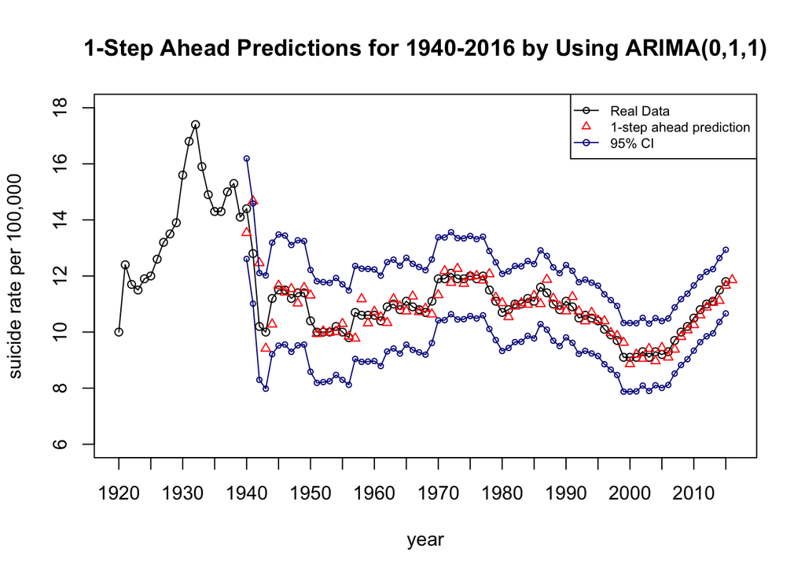

| avg.sd | avg.diff |
| --- | --- |
| 0.7427802 | 0.0212389 |

```r
pre.1step <- vector()
s.e       <- vector()
lowerCI   <- vector()
upperCI   <- vector()
estimate  <- vector()
alpha     <- 0.05

pred<-function(data,initial.box=19,prediction=0){

   for (i in 1: (nrow(suicide)-initial.box+prediction) ) {
     pre.data<-suicide[1:(initial.box+i),] ##16 year for first step
     ts.data <- ts(pre.data[,2] , start=c(1920), frequency=1)
     arma    <- arima(ts.data, order=c(0,1,1))

     pre.1step   <-predict(arma,n.ahead = 1)
     estimate[i] <- pre.1step$pred
     s.e[i]      <- pre.1step$se

     lowerCI[i] <- suicide.ts[20+i] - s.e[i]*qnorm(1-alpha/2)
     upperCI[i] <- suicide.ts[20+i] + s.e[i]*qnorm(1-alpha/2)
   }

  est.ts   <- ts(estimate,start = 1920+initial.box+1)
  cilow.ts <- ts(lowerCI,start = 1920+initial.box+1)
  ciup.ts  <- ts(upperCI,start = 1920+initial.box+1)
  avg.sd   <- mean(s.e)
  avg.diff <- mean( (estimate[1:76]-ts.data[21:96]) )

  table    <- data.frame(avg.sd,avg.diff)
  tablek   <- kable(table,booktabs=T) %>% kable_styling()
  plot(pre.data,type="o", xlim=c(1920,2016+prediction), ylim=c(6,18),
       cex=0.9, xaxt='n', ylab="suicide rate per 100,000",
       xlab="year", lty=1,main="1-Step Ahead Predictions for 1940-2016 by Using ARIMA(0,1,1)")
  axis(1, at=seq(1920,2016+prediction, by=5) )
  points(est.ts, col='red', pch=2, cex=0.8, lty=1)
  lines(cilow.ts, type='o', col='darkblue', cex=0.6, lty=1)
  lines(ciup.ts , type='o', col='darkblue', cex=0.6, lty=1)
  legend("topright", legend=c("Real Data","1-step ahead prediction","95% CI"),
         col=c("black", "red", "darkblue"), cex=0.7, lty=c(1,0,1), pch=c(1,2,1) )

  return(tablek)

  }

pred(suicide)
```

## V. Forcast: 10-steps ahead prediction 2016-2025

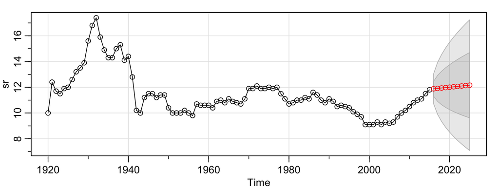

```
## $pred
## Time Series:
## Start = 2016
## End = 2025
## Frequency = 1
##  [1] 11.88087 11.91215 11.94344 11.97472 12.00600 12.03728 12.06856 12.09985
##  [9] 12.13113 12.16241
##
## $se
## Time Series:
## Start = 2016
## End = 2025
## Frequency = 1
##  [1] 0.5761048 1.0055429 1.3001294 1.5393363 1.7460745 1.9308019 2.0993370
##  [8] 2.2553127 2.4011779 2.5386759
```

```r
library(sarima)
library(astsa)
sarima.for(sr, n.ahead=10, p=0, d=1, q=1, P = 0, D = 0, Q = 0, S =0)
```

## VI. Summary

The understanding of important fact affecting suicide rate helps the society be more aware of people’s mental health during or before some negative economic changes. In a fact, the suicide rate (the U.S suicide rate in this case) may follow patterns which can be fitted into a model. A satisfied model can also provide good forecasts of suicide rate in the furfure.

In the project, The ARIMA(0,1,1) model has been used to do two different type of forcasts. On the one hand, the model looks good from some statistical examination or diagnostics. On the other hand, the model also ignores the suicide’s natural complicacy, there are many factors involved. And as time goes by, more factors that affect suidicte rate could be proved and known by scientist. Consiquently, there will be new factors to alter suicide rate. Therefore we need to always update our data, measure method, or even model. Plainly, the model this project has gotten is something that a little bit idealistic, but still can be a good reference for some institutions.